# Data Science Lab 5

Ashton Wiens

2018-02-11

# Aerosol Mass Spectrometry

In this lab you we will be exploring data obtained by a domain expert in the field of aerosol mass spectrometry. Two particles in the atmosphere were ionized and the resulting spectra were recorded. These are the variables spec5 and spec10. These spectra are indexed by the mass variable. That is, the first entry of spec5 is the recorded spectra for the mass value in the first entry of the mass variable.

(Note: mass is actually referring to the mass to charge ratio of the recorded spectra, but the atmospheric science isn’t what is important here).

Your task is to explore

- what type of variation occurs within spec5 or spec10
- what type of covariation occurs between spec5 and spec10

These features of the data should be visualizable. However, this task isn’t necessarily easy, since there is so much noise in the data. Both signals spec5 and spec10 should have a “signature” which we are going to try to visualize. *But remember* in EDA there is really no right or wrong answer, we are just explorers.

Follow allong with this guide and follow the instructions at the end of the lab.

```r
rm(list=ls()) # clears your environment variables
cat('\014')   # clears the console
suppressPackageStartupMessages(library(tidyverse) )

ms <- read_csv("https://raw.githubusercontent.com/ervance1/Sp2018-Data-Science-repo/master/ms.csv") # load the data
ls()   # show the variables in the environment
```

# Univariate Distribution

Start by visualizing one of either spec5 or spec10 by itself. Choose one of these two spectra to analyze. Get an idea for the univariate distribution of the spec variable of your choosing using `geom_histogram` and `geom_density`. Try and filter the data to make the histogram more revealing (removing small values). Don’t try too hard though. I’ll include what the histogram looks like using R’s base graphics.

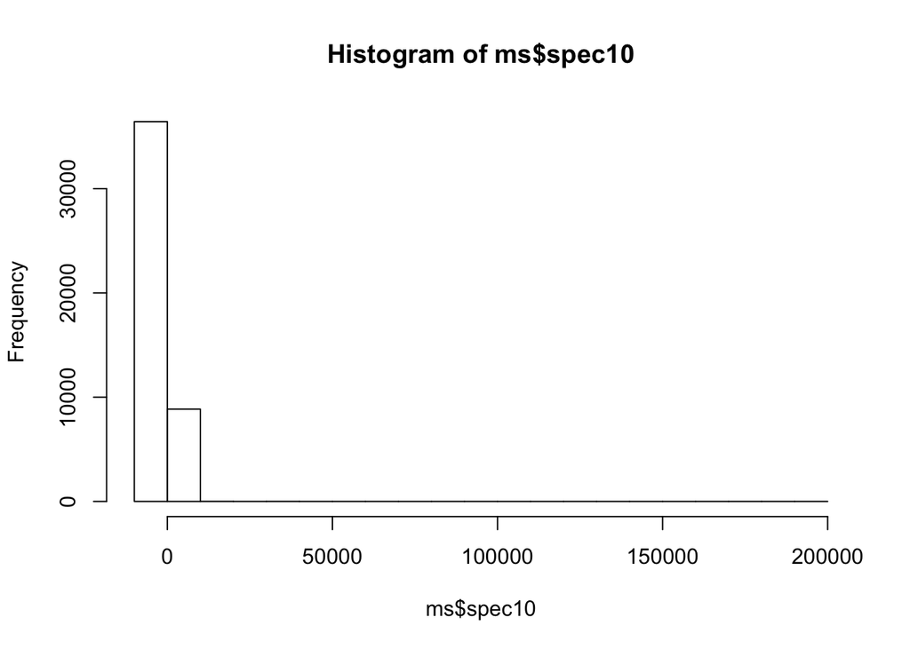

There are so many data points close to zero that it obscures where all of the other data is. Even if you filter the data or use different number of bins, the histogram is pretty uninformative. We can also try using `dplyr` to get a binned estimate of the distribution of the data:

```r
ms %>% summarize(total = length(spec5),
                 numNAs = sum(is.na(spec5)),
                 neg = length(spec5[spec5<0]),
                 zero = length(spec5[spec5==0]),
                 small = length(spec5[spec5>0 & spec5<=100]),
                 med = length(spec5[spec5>100 & spec5<=1000]),
                 large = length(spec5[spec5>1000 & spec5<=10000]),
                 realbig = length(spec5[spec5>10000 & spec5<=100000]))
```

```
## # A tibble: 1 x 8
##   total numNAs   neg  zero small   med large realbig
##   <int>  <int> <int> <int> <int> <int> <int>   <int>
## 1 45312      0   893 35006  9206   123    54      25
```

The negative values can be ignored as uninformative. The zeros are also uninformative. These can be taken care of later either with `mutate` or `filter`, then passed to `ggplot`.

# Bivariate Plots

Now we will visualize the spec variable you have chosen in relation to the mass variable. You can think of the mass variable as the “index” variable for spec. Thus, it gives an order to spec when we plot the two together.

Try using `geom_point` (with the `alpha` argument), `geom_jitter`, `geom_bin2d`, `geom_hex`, and anything else you find useful to visualize the data. The following is a scatter plot of the two variables in base R graphics.

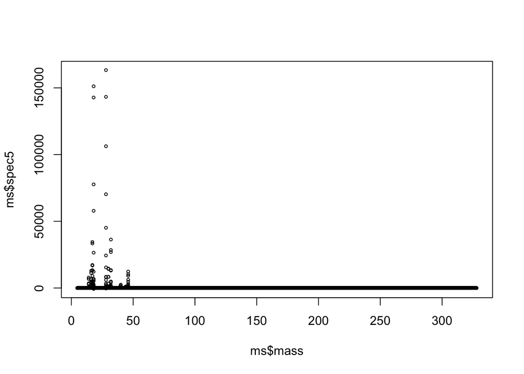

See if you can do better by using `ggplot` functions and operations in `dplyr`. You especially want to subset the data with `filter` or `mutate`. As good coding practice, you can set parameters as cutoffs/thresholds for the data. You may want to use `h` and `l` as set below.

```r
h <- 10000
l <- 1
```

Some suggestions:

- Use `dim()` to find the size of the new filtered/mutated data set (you can pipe to `dim()` )
- You can use `arrange` and `desc` to view the largest and smallest values, and `summarize` to get summary statistics as above.
- Try removing 0’s and negative values
- Subsetting by the mass variable might be useful
- You need the `hexbin` package to use `geom_hex`

# Covariance / Correlation

Finally you can explore the correlation between spec5 and spec10. The basic function for calculating the correlation between two sets of data is `cor`.

```r
cor(ms$spec5, ms$spec10)
```

```
## [1] 0.9952781
```

You can also plot spec5 versus spec10. What an interesting correlation plot.

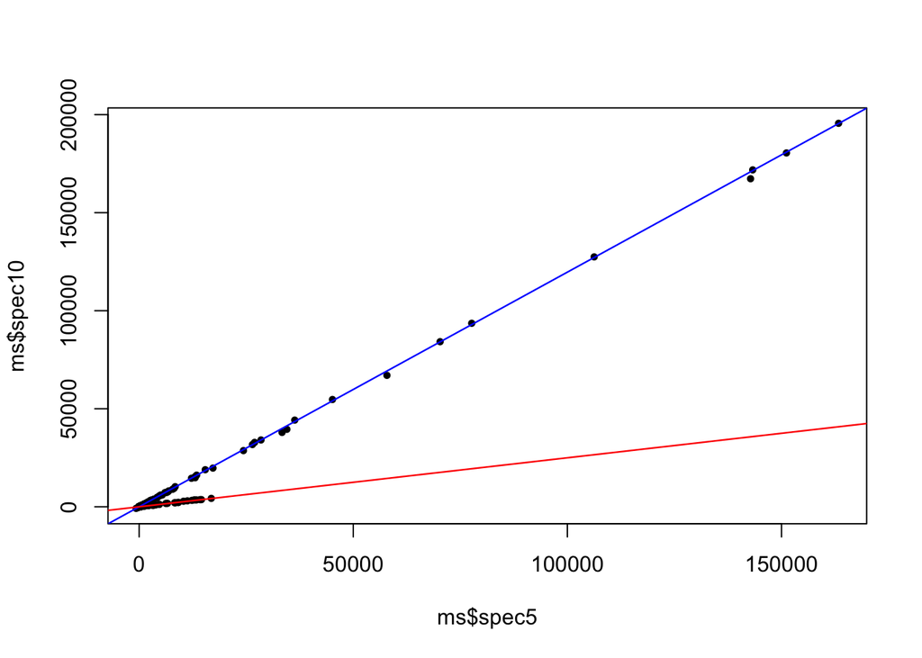

A convenient and fast way to visualize univariate distributions and pairwise relationships is by using the `ggpairs` function in the `GGally` package.

```r
library(GGally)
```

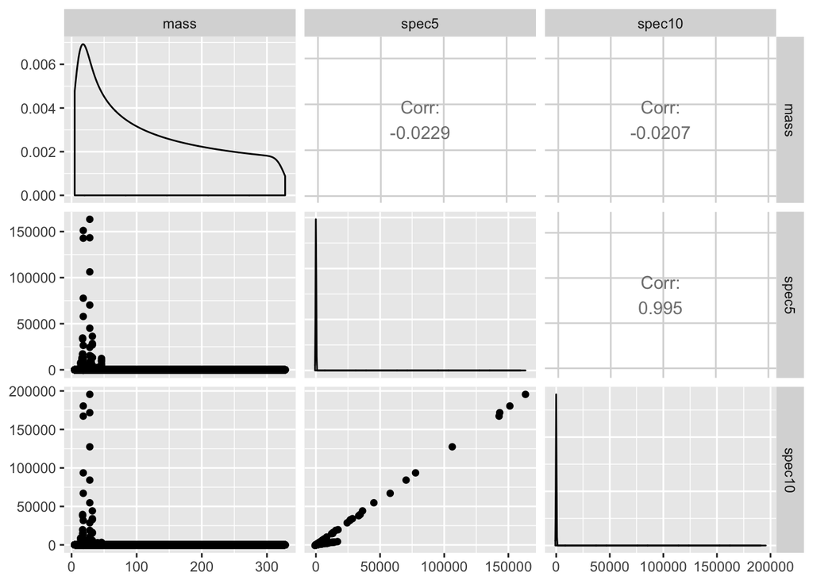

```r
ms %>% select(mass, spec5, spec10) %>% ggpairs()
```

# Final Exploration

You are given two new pieces of information.

- You should round the values in the mass variable to the nearest integer.

```r
ms <- ms %>% mutate(mass.ord = as.ordered(round(mass,0)) )
```

Now we can use mass.ord as a categorical variable in plots. The previous code creates an ordinal/categorical variable based on the rounded mass values. You can try out `geom_boxplot` and related `geom_violin`, as well as `geom_freqpoly`.

- An atmospheric scientist also suggests to you that to see the relationship between two variables, sometimes it can be helpful to look at the difference of the two. Create a new variable that is the difference between spec5 and spec10 and explore this new “signal”. Do you notice anything in the data in certain mass “categories” now when you filter and plot?
- What happens if you take the log of the spec data? Taking the `log()` of data can be useful for visualizing since there are many orders of magnitude involved. Note that negative values and 0’s must be removed when taking the log of data.

# Assignment Instructions

*Due: 5:00PM Friday, February 16, 2018 on OSF*

Individually create two plots: one which best shows the variation in the spec variable you first chose, and one which best shows the covariation between spec5 and spec10. Anything goes, and you can be creative using the tools you have learned so far.

Among everyone’s individual plots, make sure your team has at least one plot with the raw spec5 or spec10 data, one with the difference between the two, and one with log transformed data.

After everyone is finished, come together as a team and write a few sentences in the team report in R Markdown detailing what you found to be the most helpful in learning about this data. Include everyone’s individual plots. Of the eight or ten individual plots that your team made, decide as a team on one plot that you think conveys the most information about the data, and put this plot first in the report.